# Example 0: Computing the Mean Squared Error

Throughout the course, we will provide coding examples using Jupyter Notebook files like this one. Use this code to answer the questions in the Summative Assessment.

Note: we will use several libraries/packages for this class, including numpy and mathplotlib. If you wish to run this code on your local system, you will need to ensure that these packages are available for use. To install them, open up your computer terminal (Terminal for Macs or PowerShell for PCs). If you have a PC, you will type "pip install numpy" and press enter. Then you will also write "pip install matplotlib". If you have a Mac, you will replace pip with pip3: for example, "pip3 install numpy".

pip is a package manager for Pyton. Fun fact, it stands for "pip install package."

```python
# numpy is a library for arrays in python
# and it is often abbreviated to "np"
import numpy as np

# matplotlib is a library for visualizing
# mathematical equations and data.
# pyplot is specifically designed to work like MATLAB
import matplotlib.pyplot as plt
```

In the cell below, we define numpy arrays containing the information of the dataset from the problem. Numpy arrays are often more efficient computationally than a list.

```python
# Step 1: Dataset as arrays
X = np.array([0, 1, 2, 3, 4, 5, 6, 7, 8, 9])
Y = np.array([8.52810469,  8.80031442, 12.95747597, 18.4817864 , 20.73511598,
       18.04544424, 24.90017684, 25.69728558, 28.7935623 , 32.821197])
```

The 5 functions for consideration are defined and packaged into a list.

```python
# Step 2: Define five functions
def f1(x): return 2*x + 6
def f2(x): return 4*x + 4
def f3(x): return 3*x + 5
def f4(x): return x + 8
def f5(x): return 5*x + 3

functions = [f1, f2, f3, f4, f5]
```

```python
# Step 3: Compute MSE for each function
def compute_mse(f, X, Y):
    predictions = f(X)
    return np.mean((predictions - Y)**2) / len(Y)

mse_list = []
for func in functions:
    mse = compute_mse(func, X, Y)
    mse_list.append(mse)
```

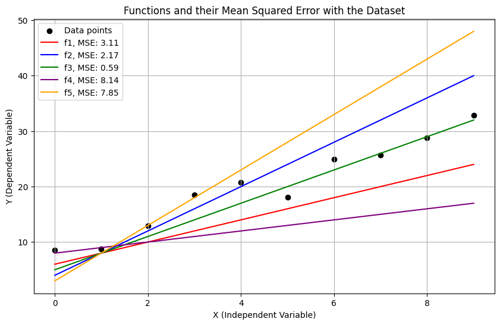

```python
# Step 4: Plot the functions, dataset, and MSEs
plt.figure(figsize=(10,6))
plt.scatter(X, Y, color='black', label='Data points')

colors = ['red', 'blue', 'green', 'purple', 'orange']

for idx, (func, color) in enumerate(zip(functions, colors)):
    plt.plot(X, func(X), color=color, label=f'f{idx+1}, MSE: {mse_list[idx]:.2f}')

plt.legend()
plt.title("Functions and their Mean Squared Error with the Dataset")
plt.xlabel("X (Independent Variable)")
plt.ylabel("Y (Dependent Variable)")
plt.grid(True)
plt.show()
```

Based on both visual inspection and the mean squared error, which function is the best fit for this data? Why?